# Final Project for BIOS 26211

**Authors:** Danny Liu and Daniel Gong

## Background

Breast cancer treatment decisions depend on molecular biomarkers — ER status, HER2 amplification, histologic grade, and intrinsic subtype — traditionally assessed through immunohistochemistry or specialized assays. RNA-seq provides genome-wide expression profiles, raising the question: **can machine learning on gene expression reliably predict these biomarkers?**

Beyond prediction, we want to understand which genes carry the signal. Classical differential gene expression (DEG) analysis tests each gene individually, but this ignores relationships between genes. Regularized linear models like LASSO fit all genes jointly, identifying which genes matter given the others. Nonlinear models like gradient boosting can capture gene-gene interactions. By comparing these three approaches, we can determine whether the predictive signal lives in individual genes, joint linear combinations, or complex interactions.

**Main questions:**

1. Which individual genes are differentially expressed between ER+ and ER- tumors?
2. Which genes jointly predict biomarker status when modeled together?
3. Do nonlinear gene-gene interactions improve prediction beyond linear models?

Danny: project design, code implementation, model training | Daniel: background research, biological interpretation, conclusions

### References

1. Brueffer et al. (2018). Clinical Value of RNA Sequencing-Based Classifiers for Prediction of the Five Conventional Breast Cancer Biomarkers. *JNCI*.
2. Parker et al. (2009). Supervised Risk Predictor of Breast Cancer Based on Intrinsic Subtypes. *JCO*.
3. Hastie, Tibshirani, Friedman. *The Elements of Statistical Learning*. Springer.
4. James et al. *An Introduction to Statistical Learning*. Springer.

## The Data

We use the **GSE96058** dataset from the SCAN-B (Sweden Cancerome Analysis Network – Breast) initiative, which profiled 3,273 primary breast tumors using RNA-seq. The expression matrix contains ~30,000 genes per sample. Clinical annotations include ER status, HER2 status, NHG histologic grade (1-3), and PAM50 intrinsic subtype (Luminal A, Luminal B, Her2-enriched, Basal, Normal-like).

**Target variable distributions:**

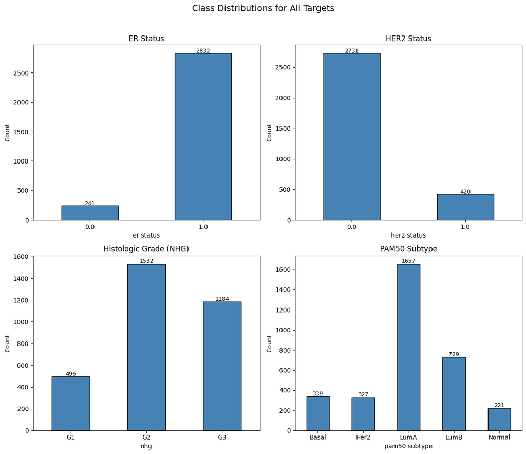

Figure 1: Distribution of the four target variables across the cohort.

**Data cleaning pipeline:**

- Sentinel values (log2(0.1) = -3.32) treated as missing — none found after filtering
- Genes with >50% NaN removed, then variance-based filter retaining top 5,000 genes
- 80/20 stratified train/test split for each target, preserving class proportions

Danny: data loading, cleaning pipeline, train/test split design

## Methods

We use three progressively sophisticated approaches to identify predictive genes:

1. **Regularized Logistic Regression (LASSO & Ridge):** fit all genes jointly with regularization
2. **Differential Gene Expression (DEG):** test each gene individually (classical approach)
3. **HistGradientBoosting:** capture nonlinear gene-gene interactions

We first perform exploratory data analysis to understand the structure of the expression space.

### Exploratory Data Analysis

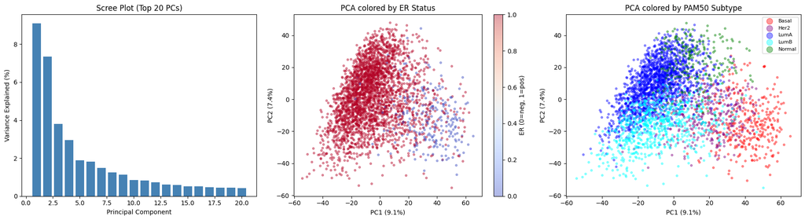

Figure 2: PCA of gene expression colored by ER status and PAM50 subtype. ER-negative (Basal) tumors separate clearly along PC1.

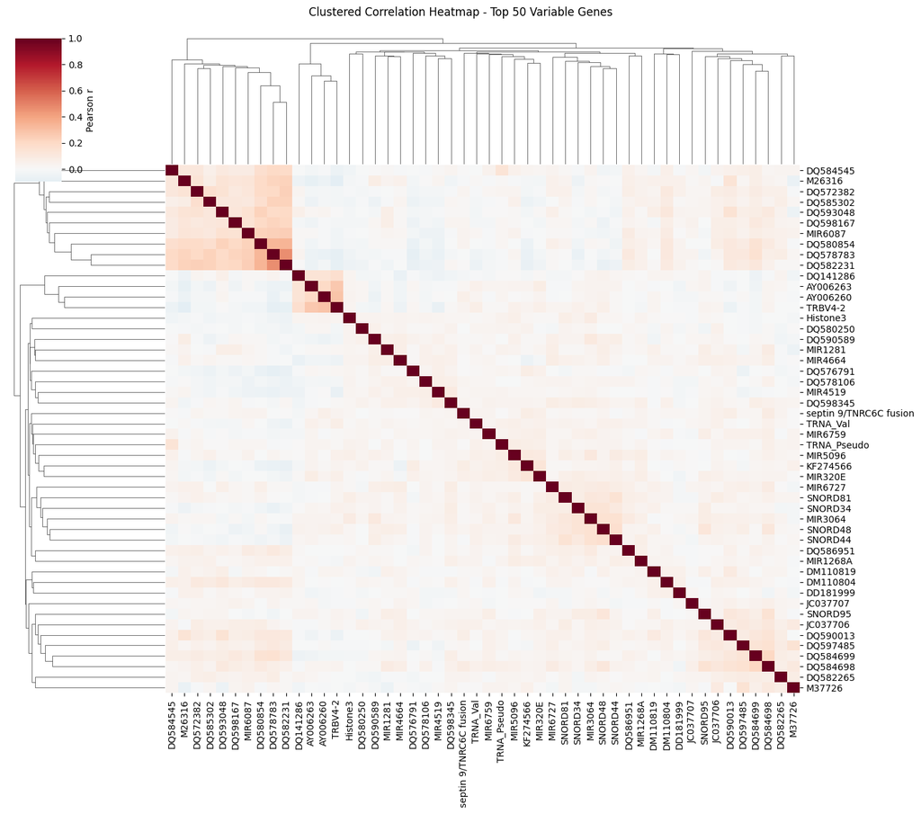

Figure 3: Correlation heatmap of the 50 most variable genes.

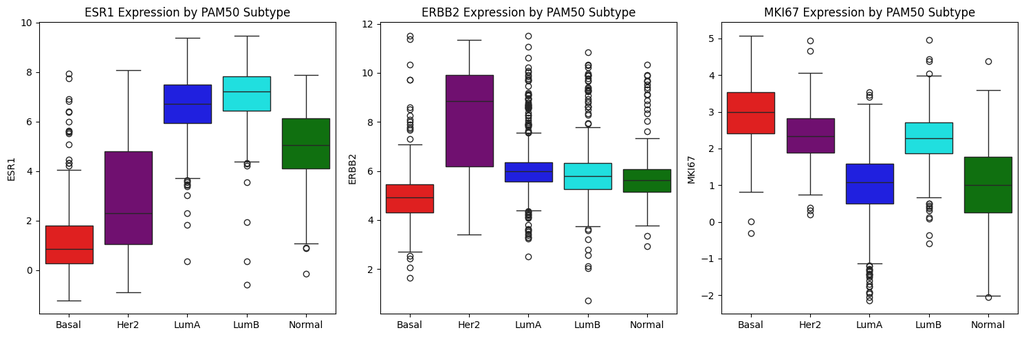

Figure 4: Expression of canonical marker genes across PAM50 subtypes.

**Key EDA observations:**

- **PCA** shows clear separation of ER-negative (Basal) tumors along PC1, consistent with known breast cancer biology.
- **PAM50 subtypes** form partially overlapping clusters: Basal is most distinct; Luminal A and B overlap considerably.
- **ESR1** shows highest expression in Luminal subtypes and lowest in Basal, confirming ER status should be highly predictable.
- **ERBB2** expression is elevated specifically in Her2-enriched tumors.

Danny: EDA implementation

### Method 1: Regularized Logistic Regression (LASSO & Ridge)

We train Ridge (L2) and LASSO (L1) logistic regression on all ~5,000 genes simultaneously using 10-fold stratified cross-validation. Unlike DEG, these methods account for correlations between genes — LASSO zeros out redundant features while Ridge shrinks all coefficients.

**ER Status Results:**

- Best Ridge: C=0.001, CV AUC = 0.9748
- Best LASSO: C=0.1, CV AUC = 0.9710
- LASSO selected 162 / 5,000 non-zero coefficients

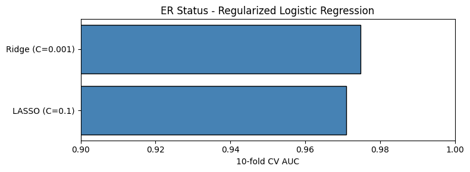

Figure 5: Ridge vs LASSO performance comparison for ER status prediction.

We then applied Ridge and LASSO to all four targets: ER status, HER2 status, NHG grade, and PAM50 subtype.

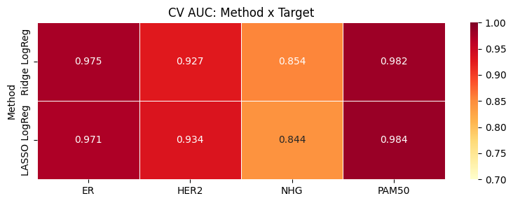

Figure 6: Cross-validation AUC across all targets and model types.

Danny: model implementation, tuning, and multi-target pipeline

### Method 2: Differential Gene Expression Analysis

We perform genome-wide differential expression testing between ER+ and ER- tumors using two-sample t-tests for each of the ~5,000 genes. We apply Benjamini-Hochberg FDR correction and visualize results with a volcano plot. This is the classical single-gene approach — we compare its gene selections with LASSO's joint selections.

- Significant genes (adj_p < 0.05): 3,531 / 5,000
- Significant AND |log2FC| > 1: 1,273 genes

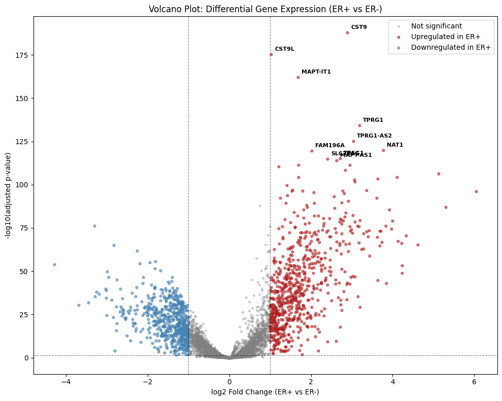

Figure 7: Volcano plot showing log2 fold change vs. -log10(adjusted p-value) for all genes.

Danny: implementation | Daniel: interpretation

### Method 3: HistGradientBoosting (Nonlinear)

Linear models assume class boundaries are hyperplanes. Gradient boosting builds decision trees that naturally capture gene-gene interactions — if gene A is high AND gene B is low, predict a different class. If HistGBoost outperforms LASSO, it means gene combinations carry signal beyond individual genes.

HistGradientBoosting matched but did not outperform linear models, confirming that the biomarker boundaries in expression space are approximately linear.

Danny: implementation and comparison

## Results

### Results 1: Test Set Evaluation & Statistical Validation

We evaluate the best model per target on held-out test data:

| Target | Test AUC | Test Accuracy |
| --- | --- | --- |
| ER | 0.9561 | 96.75% |
| HER2 | 0.9117 | 92.71% |
| NHG | 0.8399 | 68.43% |
| PAM50 | 0.9847 | 88.70% |

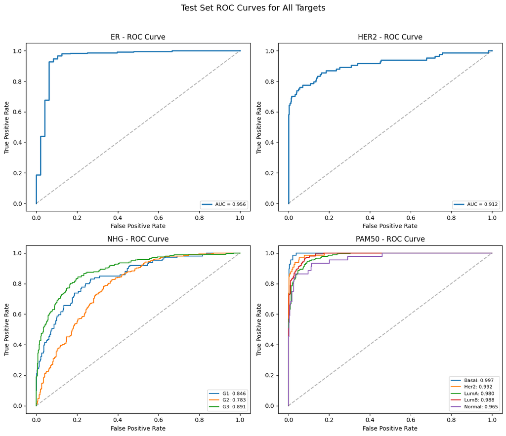

Figure 8: ROC curves for the best model per target on held-out test data.

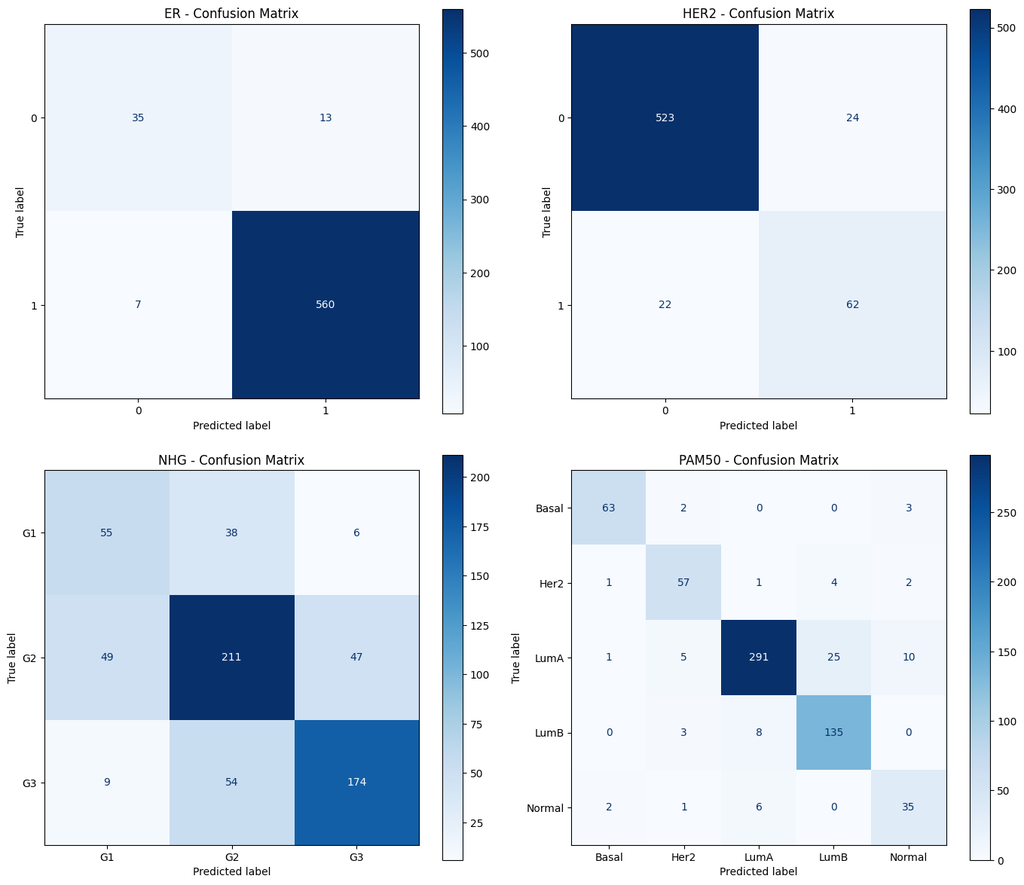

Figure 9: Confusion matrices for all four targets on the test set.

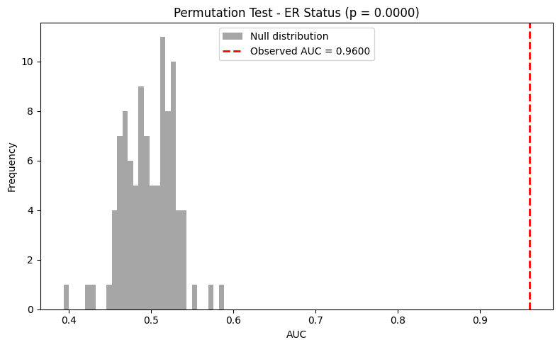

Figure 10: Permutation test for ER status — observed AUC vs. null distribution (100 permutations, p < 0.01).

Danny: test evaluation, statistical testing

### Results 2: Feature Selection & Biological Interpretation

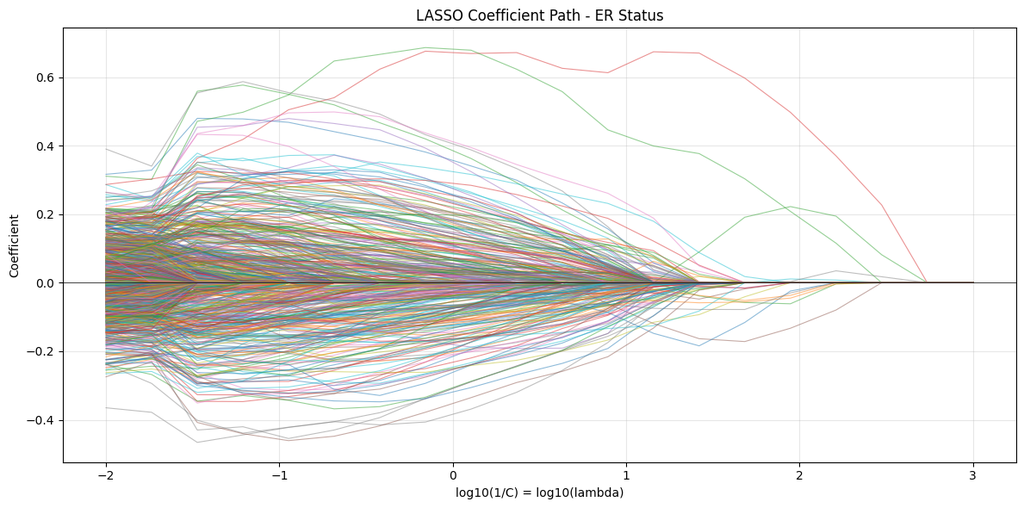

Figure 11: LASSO coefficient path showing how gene coefficients change with regularization strength.

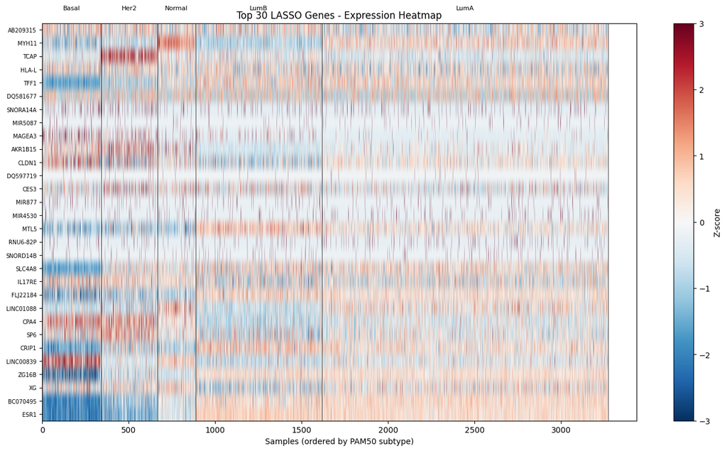

Figure 12: Expression heatmap of top 30 LASSO-selected genes, ordered by PAM50 subtype.

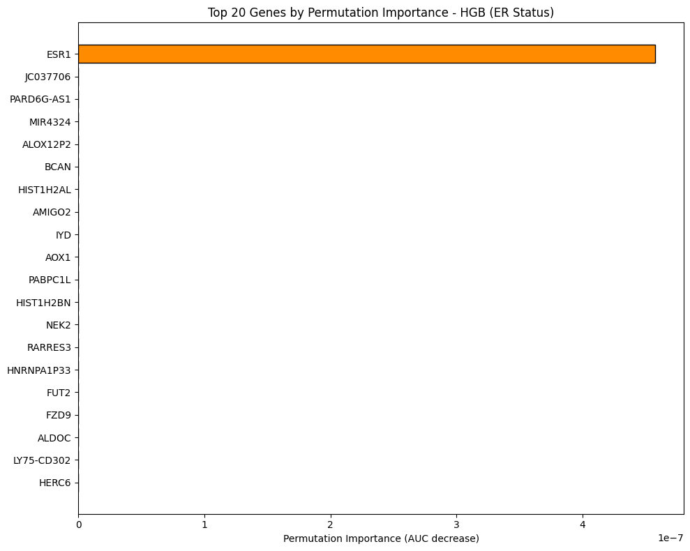

Figure 13: Feature importance from HistGradientBoosting (ER status).

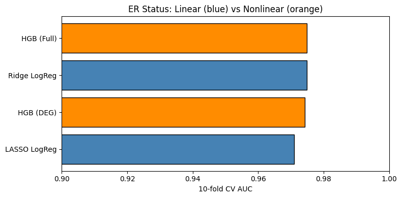

Figure 14: Full comparison of Ridge vs LASSO vs HistGradientBoosting for ER status.

Danny: feature selection analysis | Daniel: biological interpretation

## Conclusions

**New Questions Raised:**

- Would these results replicate on independent cohorts (TCGA, METABRIC)?
- Can pathway-level features (gene set enrichment) provide more interpretable models?
- Would integrating clinical features (age, tumor size) improve predictions for harder targets like NHG?

**Limitations:**

- Single dataset (SCAN-B) — external validation needed
- DEG analysis limited to ER status (binary); multiclass targets would need ANOVA
- Gene expression only — no clinical covariates integrated
- Variance-based gene filter may miss low-variance predictive genes

Daniel: conclusions and interpretation

## References

1. Brueffer et al. (2018). Clinical Value of RNA Sequencing-Based Classifiers for Prediction of the Five Conventional Breast Cancer Biomarkers. *JNCI*. [doi:10.1093/jnci/djy156](https://doi.org/10.1093/jnci/djy156)
2. Parker et al. (2009). Supervised Risk Predictor of Breast Cancer Based on Intrinsic Subtypes. *JCO*. [doi:10.1200/JCO.2008.18.1370](https://doi.org/10.1200/JCO.2008.18.1370)
3. Hastie, Tibshirani, Friedman. *The Elements of Statistical Learning*. Springer. [Link](https://hastie.su.domains/ElemStatLearn/)
4. James et al. *An Introduction to Statistical Learning*. Springer. [Link](https://www.statlearning.com/)